# IS607 Project-3 Summary

Is Best Film Editing is the best predictor of Best Picture ?

### Introduction

**Primary Objective: “In the Academy Awards, What is the best predictor of Best Picture ?”**

[Click Here](http://rpubs.com/nathanlim45/introduction) for details on Award Categories, Desired Outcomes, Assumptions, Constraints, Possible Benefit, and Strategy !

### Data Acquisition & Transformation

**“Acquire the data and Tranform it !”**

[Click Here](http://rpubs.com/skhan/69766) for details on the *Data Source* and *Data Transformation*

### Data Tidying & Reshaping for Analysis

**“Tidy & Reshape the data for analysis”**

*Here are few links that includes the “data tidying” as a pre-processing step to the analysis*

[Points based approach](https://rpubs.com/senthiltamil/Project3)

[Analysis based on Conditional Probability](http://rpubs.com/msekhar12/68495)

[Decision Tree](http://rpubs.com/jetherton/70678)

[Predictive Modeling](http://www.rpubs.com/dn11/70696)

### Analysis 1 - Points based approach

- *If Best Picture movie was also nominated on other categories then those categories get one point*
- *If the BEST Picture movie also won in other categories then those categories get two points. Categories with most points are the best indicators or predictors of Best picture movie.*

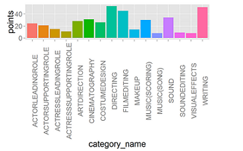

**Conclusion: Directing Category can be used a good indicator to PREDICT the BEST PICTURE.**

[Click Here for Complete Analysis](https://rpubs.com/senthiltamil/Project3)

### Analysis 2 - Using 'Bayes' formula

- *Probability of getting Best Movie, given that the movie is nominated in a paricular award category ?*

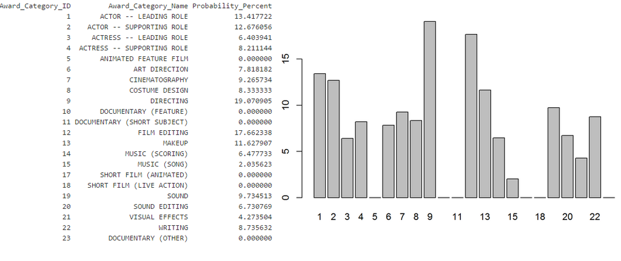

### Analysis 2 - Using 'Bayes' formula

- *Probability of getting Best Movie, given that the movie wins in a paricular award category ?*

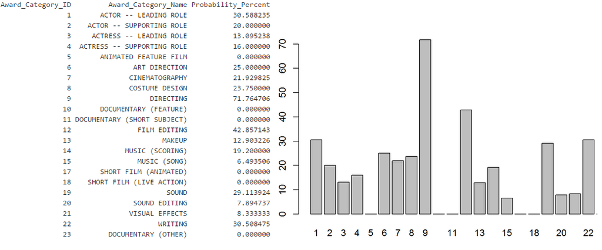

**Conclusion: Directing Category can be used a good indicator to PREDICT the BEST PRICTURE.**

[Click Here for Complete Analysis](http://rpubs.com/msekhar12/68495)

### Analysis 3 - Using 'Decision Tree'

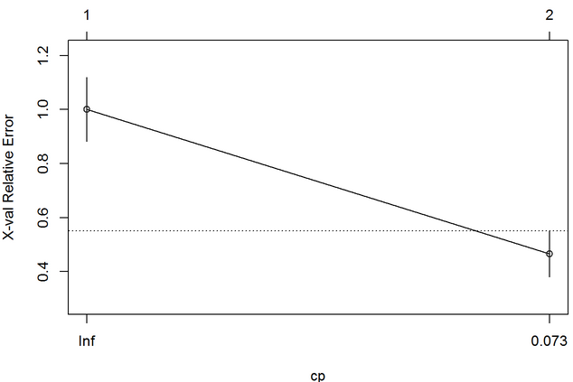

**Conclusion: Directing Category can be used a good indicator to PREDICT the BEST PRICTURE.**

[Click Here for Complete Analysis](http://rpubs.com/jetherton/70678)

### Analysis 4 - Applying Modeling Techniques

*Different modeling techniques ( CART, Bagged Trees, Random Forests ) have been applied in the above analysis.*

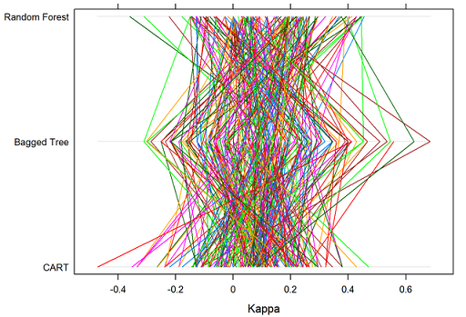

**Conclusion: No definitive conclusion may be drawn here.**

[Click Here for Complete Analysis](http://www.rpubs.com/dn11/70696).

### Visualizations

**Distribution of Nominations By Category**

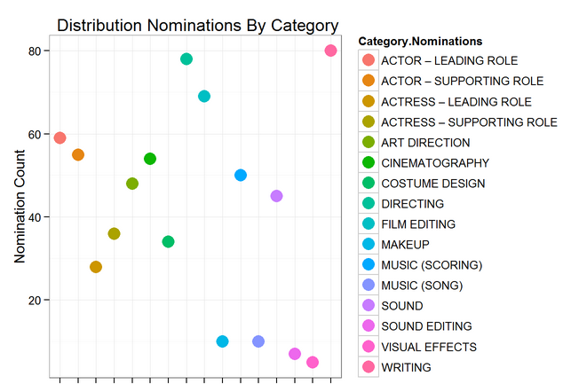

[Click here for Visualizations Rpubs](http://rpubs.com/HoneyBerk/proj3datavis)

### Visualizations

**Distribution of Winning By Category**

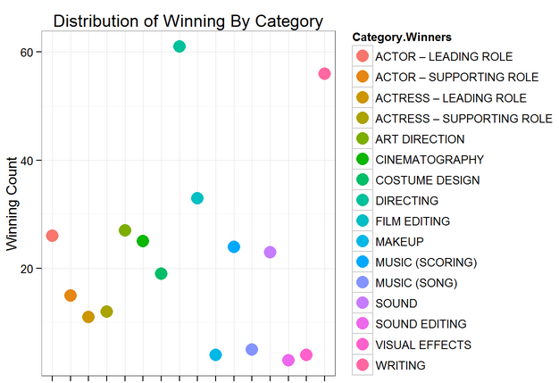

[Click here for Visualizations Rpubs](http://rpubs.com/HoneyBerk/proj3datavis)

### Visualizations

**Distribution of Wins over Winning by Nominations Category**

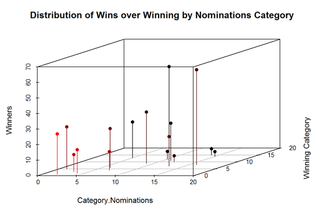

[Click here for Visualizations Rpubs](http://rpubs.com/HoneyBerk/proj3datavis)

### Visualizations

**Correlation Matrix**

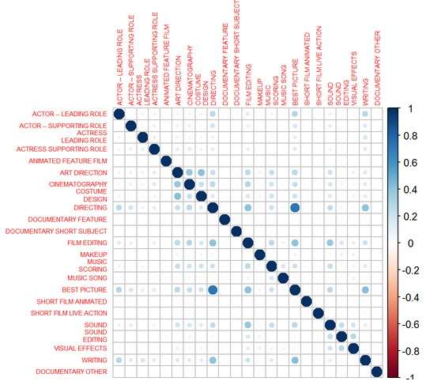

[Click here for Visualizations Rpubs](http://rpubs.com/HoneyBerk/proj3datavis)

### Conclusion

- **Majority of our analysis concludes that the Best Film Editing is NOT the best predictor of Best Picture**
- **Also, most of the approaches suggests that the *Directing Category* can be used a good indicator to predict the *BEST PICTURE*.**

[figure not shown]

[figure not shown]

[figure not shown]

### Reference Links

**github**

https://github.com/srajeev1/607Project3

**rpubs**

http://rpubs.com/nathanlim45/introduction http://rpubs.com/skhan/69766 https://rpubs.com/senthiltamil/Project3 http://rpubs.com/msekhar12/68495 http://rpubs.com/jetherton/70678 http://rpubs.com/simonnyc/70716 http://rpubs.com/HoneyBerk/proj3datavis http://rpubs.com/dn11/70696 http://rpubs.com/jhamski/Project3_EDAvis